# 🧭 Calcular o Tamanho Amostral

## 🧮 Por que o cálculo de tamanho amostral é importante?

🩺 **Cenário 1**

Suponha que um hospital quer testar se um novo medicamento reduz a pressão arterial em comparação com o tratamento padrão. Eles fazem um estudo com 30 pacientes em cada grupo (medicamento novo vs. tratamento padrão), mas não encontram diferença estatisticamente significativa. No entanto, o poder estatístico do estudo era de apenas 50%. Isso quer dizer que, mesmo que o novo medicamento realmente funcione, há 50% de chance de o estudo não detectar esse efeito.

- Consequência 1: Amostra pequena → risco de erro tipo II. O estudo pode concluir, incorretamente, que o medicamento não funciona, simplesmente por não ter pacientes suficientes para mostrar a diferença.

🩺 **Cenário 2**

Imagine que outro hospital faz um estudo com 200 pacientes, e encontra uma pequena diferença (por exemplo, redução de 2 mmHg na pressão). No final, percebe-se que o efeito é muito grande (d = 1), e que só seriam necessários 46 pacientes para atingir 90% de poder.

- Consequência 2: Amostra desnecessariamente grande Recursos foram desperdiçados: exames, equipe, tempo de pacientes, e dinheiro da pesquisa foram além do necessário.

**✅ Moral da história**: O tamanho amostral ideal é aquele que minimiza o risco de não encontrar um efeito verdadeiro, sem exagerar no número de participantes. Isso garante eficiência, ética e qualidade científica.

## ⚜️ Através do GPower

#### ✅ O que é o G*Power

O G*Power é um software gratuito, disponível para Windows e Mac OS, usado para calcular o tamanho amostral em diferentes testes estatísticos

[figure not shown]

O G*Power realiza cinco tipos principais de análise de poder:

- Análise a priori: calcula o tamanho amostral mínimo necessário para detectar um efeito, com base nos níveis de significância e poder desejados;
- Análise de compromisso: calcula a relação entre erros Tipo I (α) e Tipo II (β), com base na razão β/α, no tamanho amostral e no tamanho de efeito populacional;
- Análise de critério: calcula o nível de significância necessário, dado o poder, o tamanho da amostra e o tamanho de efeito esperado;
- Análise post hoc: estima o poder de um estudo após a coleta de dados, com base na amostra e nos níveis de significância e tamanho de efeito;
- Análise de sensibilidade: determina o menor efeito que pode ser detectado, considerando o poder, o nível de significância e a amostra definidos.

#### ✅ Baixe e instale o G*Power

- Site oficial: https://www.psychologie.hhu.de/arbeitsgruppen/allgemeine-psychologie-und-arbeitspsychologie/gpower
- Compatível com Windows e Mac.
- Após instalar, abra o programa.
- Para acessar o manual: https://www.psychologie.hhu.de/fileadmin/redaktion/Fakultaeten/Mathematisch-Naturwissenschaftliche_Fakultaet/Psychologie/AAP/gpower/GPowerManual.pdf

#### ✅Escolha o tipo de teste

- No menu suspenso “Test family”, você escolhe a família de testes
- Em “Statistical test”, você escolhe o tipo de teste

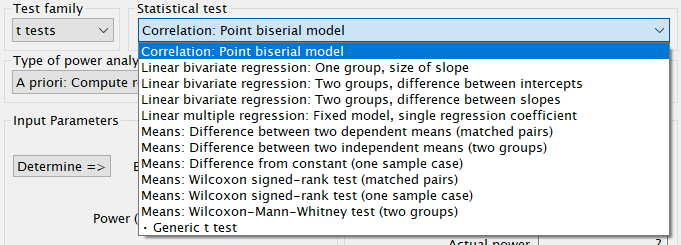

#### ✅Escolha o tipo de cálculo

Em “Type of power analysis”, selecione:

- Análise a priori: calcula o tamanho amostral mínimo necessário para detectar um efeito, com base nos níveis de significância e poder desejados;
- Análise de compromisso: calcula a relação entre erros Tipo I (α) e Tipo II (β), com base na razão β/α, no tamanho amostral e no tamanho de efeito populacional;
- Análise de critério: calcula o nível de significância necessário, dado o poder, o tamanho da amostra e o tamanho de efeito esperado;
- Análise post hoc: estima o poder de um estudo após a coleta de dados, com base na amostra e nos níveis de significância e tamanho de efeito;
- Análise de sensibilidade: determina o menor efeito que pode ser detectado, considerando o poder, o nível de significância e a amostra definidos.

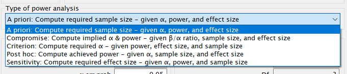

#### ✅Preencha os parâmetros

Adicione os parâmetros para cálculo:

[output not shown]

**Botão Determine para Tamanho do efeito:**

Ao lado do campo Effect size d, o G*Power tem um botão chamado “Determine”. Ele serve para te ajudar a calcular automaticamente o tamanho do efeito

#### ✅ Clique em “Calculate”

O G*Power mostrará o resultado no campo “Output parameters”.

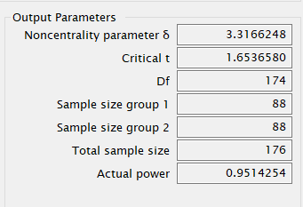

#### ✅ Visualize o gráfico

Clique em “X-Y plot for a range of values”. Escolha, por exemplo, variar o tamanho do efeito e ver como isso afeta o tamanho amostral. Clique em “Draw Plot”.

[figure not shown]

#### ✅ Salve ou exporte

Use o menu “File” → “Save” ou “Export” para guardar o relatório.

#### ✅ Exemplos

**Exemplo: Avaliação do efeito de uma intervenção em qualidade do sono**

Vamos replicar um protocolo de intervenção com musicoterapia para melhora da qualidade do sono de pacientes com insônia leve.

A qualidade do sono será avaliada por uma escala validada (pontuação de 0 a 100) antes e depois de uma semana de sessões de musicoterapia.

O estudo original apresentou apenas estatísticas descritivas:

- Pré-intervenção: 𝑀édia = 62.4, DP=9.8
- Pós-intervenção: 𝑀édia = 70.6, DP=10.1

O estudo não reportou o tamanho de efeito (Cohen’s d).

Primeiramente, selecionaremos as seguintes opções no G*Power:

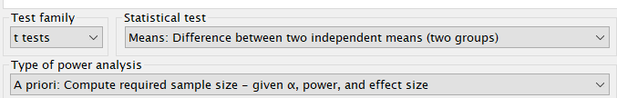

Como o estudo original não forneceu o valor de d de Cohen, clicamos no botão “Determine” ao lado do campo “Effect size d” e inserimos:

- Média 1: 62.4
- Média 2: 70.6
- Desvio padrão 1: 9.8
- Desvio padrão 2: 10.1

Clicamos em “Calculate and transfer to main window”, e o G*Power calcula automaticamente um tamanho de efeito aproximado → d ≈ 0.82 (grande)

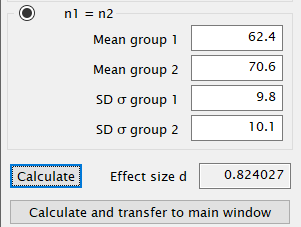

OBS: Alternativamente, é possível remeter a estudos anteriores para definir tamanho do efeito.

Após isso, colocamos os parâmetros do teste, geralmente:

- Tail(s): Two (teste bicaudal)
- α err prob: 0.05
- Power (1 - β): 0.80

Clicamos em Calculate.

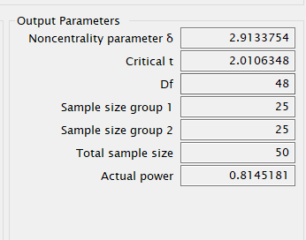

Gráficos para interpretação de variações nos parâmetros

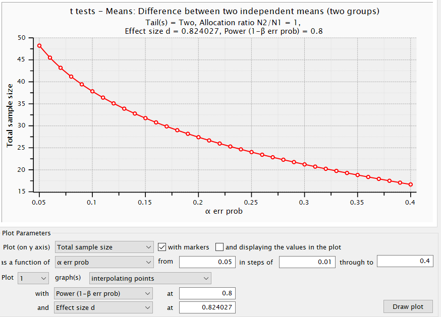

Esse é um gráfico de sensibilidade que mostra como o número total necessário de participantes muda conforme o nível de significância (𝛼) varia, mantendo fixos: Poder estatístico (1 - β): 0.80 (80%); Tamanho do efeito (d): 0.824027; Teste: t para médias independentes (dois grupos); Tail(s): Two (teste bicaudal);Razão N2/N1: 1 (mesmo número de pessoas por grupo). No eixo X, representa o nível de significância (α), ou seja, a probabilidade de erro tipo I (rejeitar uma hipótese nula verdadeira). Varia de 0.05 a 0.40 no gráfico. No eixo Y, representa o tamanho total da amostra necessário (soma dos dois grupos) para manter o poder de 80% para detectar um efeito de d = 0.82, dado o nível de 𝛼. Pelo gráfico, vemos que quanto maior o α: Mais fácil é rejeitar a hipótese nula. Então, menos participantes são necessários para atingir o mesmo poder estatístico.

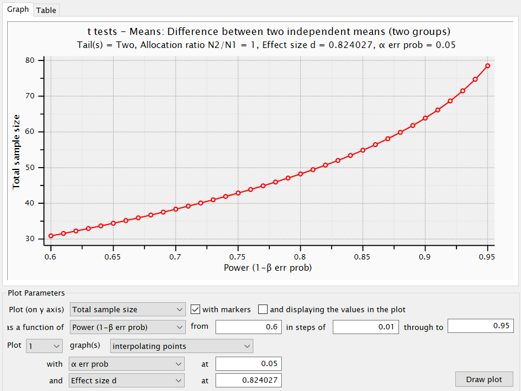

Esse gráfico demonstra a sensibilidade do tamanho total ao poder estatístico para detectar um efeito de tamanho fixo. No eixo X (horizontal): Mostra o poder estatístico desejado (1 - β), que representa a probabilidade de detectar um efeito real. Varia de 0.60 a 0.95. No eixo Y (vertical): Mostra o tamanho total da amostra necessária para atingir o poder correspondente no eixo X. Pelo gráfico vemos que quanto maior o poder exigido, mais participantes você precisa. Isso acontece porque quanto maior o poder desejado, menor a chance de aceitar um falso negativo (erro tipo II), e isso exige mais dados para ganhar precisão. O ponto ótimo usado na maioria das pesquisas (poder de 80%) equilibra custo e confiabilidade, mas dependendo do contexto clínico, valores maiores podem ser justificáveis.

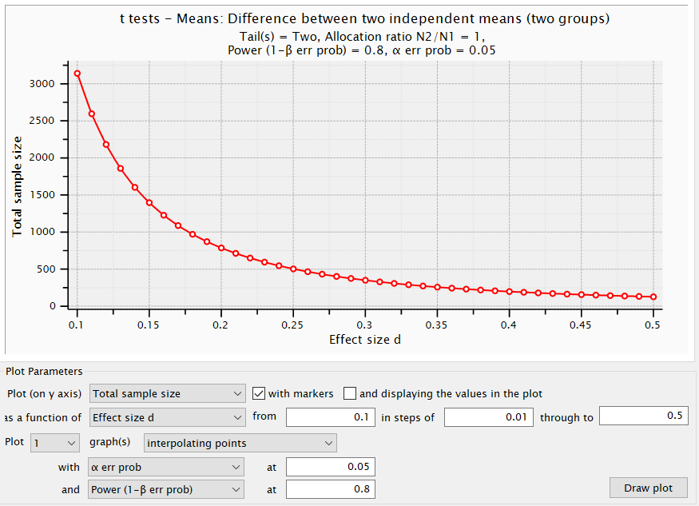

Esse último gráfico mostra como o tamanho do efeito (Cohen’s d) afeta o tamanho total da amostra necessária, mantendo os demais parâmetros fixos. No eixo X: Tamanho do efeito (Cohen’s d) — varia de 0.1 a 0.5. E no eixo Y: Tamanho total da amostra necessária (soma dos dois grupos). Pelo gráfico vemos que quanto menor o efeito que você quer detectar, maior precisa ser sua amostra. Isso acontece porque é mais difícil detectar efeitos sutis com confiança — exige mais dados para “ter certeza” de que eles existem.

#### ✅Limitações

No entanto, apesar de sua ampla utilidade, o GPower também apresenta algumas limitações. Por exemplo, ele não realiza cálculos de tamanho amostral para estudos focados em variáveis latentes, como em análises fatoriais ou modelagem por equações estruturais. Além disso, o GPower não oferece suporte para estudos que utilizam a teoria de resposta ao item ou que aplicam modelos lineares mistos.

## ⚜️ Através de Python

###### **Exemplo: Avaliação do efeito de uma intervenção em qualidade do sono**

```python
!pip install statsmodels --quiet
```

```python
from statsmodels.stats.power import TTestPower
import numpy as np
```

```python
# Parâmetros do estudo
media_pre = 62.4
media_pos = 70.6
dp_pre = 9.8
dp_pos = 10.1
correlacao_pareada = 0.5  # suposição, como no exemplo do G*Power
```

```python
from statsmodels.stats.power import TTestIndPower

effect_size = 0.82  # Cohen's d
alpha = 0.05
power = 0.8

analysis = TTestIndPower()
n = analysis.solve_power(effect_size=effect_size, alpha=alpha, power=power, alternative='two-sided')
n_ceil = int(np.ceil(n))

print(f'Tamanho amostral necessário (por grupo): {n_ceil}')
print(f'Tamanho amostral total (2 grupos): {n_ceil * 2}')
```

```
Tamanho amostral necessário (por grupo): 25
Tamanho amostral total (2 grupos): 50
```